# Deep learning framework example: Clickbate dataset

**Important**: Please see the [MNIST notebook example](https://github.com/plandes/deeplearn/blob/master/notebook/mnist.ipynb) in the [zensols.deeplearn](https://github.com/plandes/deeplearn) API first, as it contains more explaination of how the framework is used.

See the [saved notebook](https://htmlpreview.github.io/?https://github.com/plandes/deepnlp/blob/master/example/clickbate/notebook/clickbate.html) to see the output of this example.

```python
# environemnt configuration and set up: add this (deepnlp) library to the Python path and framework entry point
from mngfac import JupyterManagerFactory
fac = JupyterManagerFactory()
mng = fac()
```

Use the factory to create the model executor. The `write` method gives statistics on the data set that is configured on the executor. Note that the first time this runs, the framework automatically downloads the corpus, vectorizers and creates batches for quick experimentation.

```python
# read the configuration from glove.conf using the same command line process to load the config and models
facade = mng.create_facade('glove_50')
mng.write()
```

```
executor:
    model: clickbate: glove_50
    feature splits:
        split stash splits:
```

```
patool: Extracting ../corpus/cb_data_resource.gz ...
patool: running '/usr/bin/pigz' -c -d -- '../corpus/cb_data_resource.gz' > '../corpus/cb_data_resource'
patool:     with shell='True'
patool: ... ../corpus/cb_data_resource.gz extracted to `../corpus'.
```

```
2022-08-08 15:27:55,205 parsing ../corpus/cb_data_resource with label y
2022-08-08 15:27:55,243 parsing ../corpus/non_cb_data_resource with label n
```

```
patool: Extracting ../corpus/non_cb_data_resource.gz ...
patool: running '/usr/bin/pigz' -c -d -- '../corpus/non_cb_data_resource.gz' > '../corpus/non_cb_data_resource'
patool:     with shell='True'
patool: ... ../corpus/non_cb_data_resource.gz extracted to `../corpus'.
            test: 3201 (10.0%)
            validation: 3201 (10.0%)
            train: 25598 (80.0%)
            total: 32000
        total this instance: 32000
        keys consistent: True
    batch splits:
        split stash splits:
            test: 17 (10.5%)
            validation: 17 (10.5%)
            train: 128 (79.0%)
            total: 162
        total this instance: 162
        keys consistent: True
```

## Baseline model

Clear language attributes for a baseline to get a feel for where they need to be before changing features. Start with Glove 50 dimensional word embeddings (set in the last cell).

```
tr: 25.05|va min:24.836|va:24.877|lr: 0.001 /\: 100%|██████████| 35/35 [01:29<00:00,  2.56s/it]
```

```
Name: clickbate: glove_50: 1
Run index: 2
Learning rate: 0.001
    train:
        started: 08/08/2022 15:31:17:735761
        ended: 08/08/2022 15:32:46:422710
        batches: 128
        ave data points per batch/total: 200.0/25598
        min/ave/max loss: 13.60773/25.04998/50.46986
    validation:
        started: 08/08/2022 15:31:18:892037
        ended: 08/08/2022 15:32:46:448577
        batches: 17
        ave data points per batch/total: 188.3/3201
        converged/epochs: 34/35
        min/ave/max loss: 0.00016/24.83609/40.25769
        accuracy: 0.949 (3038/3201)
        micro: F1: 0.949, precision: 0.949, recall: 0.949
        macro: F1: 0.949, precision: 0.949, recall: 0.949
        weighted: F1: 0.949, precision: 0.949, recall: 0.949
    test:
        started: 08/08/2022 15:32:47:798103
        ended: 08/08/2022 15:32:47:823480
        batches: 17
        ave data points per batch/total: 188.3/3201
        min/ave/max loss: 0.00027/23.05570/34.50279
        accuracy: 0.954 (3054/3201)
        micro: F1: 0.954, precision: 0.954, recall: 0.954
        macro: F1: 0.954, precision: 0.954, recall: 0.954
        weighted: F1: 0.954, precision: 0.954, recall: 0.954
```

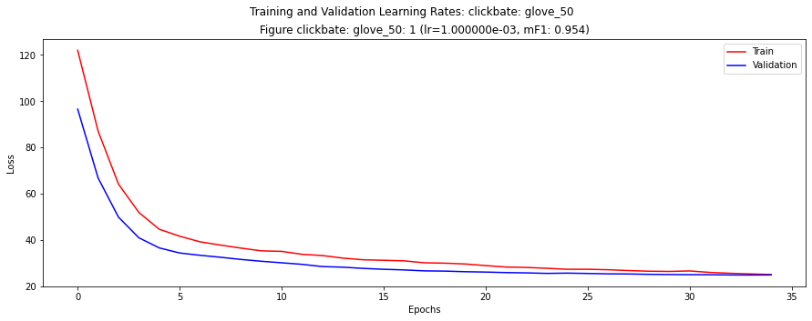

```python
# remove language features for a baseline, then add back later
facade.language_attributes = set()
mng.run()
facade.persist_result()
```

# Tune parameters

Try a lower learning rate for more epochs to see if it improves performance. Over estimating the epoch count is hedged by the model only saving on validation loss decreases.

```
tr: 22.99|va min:23.995|va: 24.01|lr:0.0009 /\: 100%|██████████| 50/50 [01:52<00:00,  2.24s/it]
```

```
Name: clickbate: glove_50: 1
Run index: 2
Learning rate: 0.0009
    train:
        started: 08/08/2022 15:32:52:302915
        ended: 08/08/2022 15:34:43:137479
        batches: 128
        ave data points per batch/total: 200.0/25598
        min/ave/max loss: 10.52305/22.99023/39.86176
    validation:
        started: 08/08/2022 15:32:53:321125
        ended: 08/08/2022 15:34:43:163668
        batches: 17
        ave data points per batch/total: 188.3/3201
        converged/epochs: 43/50
        min/ave/max loss: 0.00004/23.99468/34.68496
        accuracy: 0.949 (3039/3201)
        micro: F1: 0.949, precision: 0.949, recall: 0.949
        macro: F1: 0.949, precision: 0.949, recall: 0.949
        weighted: F1: 0.949, precision: 0.949, recall: 0.949
    test:
        started: 08/08/2022 15:34:44:900416
        ended: 08/08/2022 15:34:44:926388
        batches: 17
        ave data points per batch/total: 188.3/3201
        min/ave/max loss: 0.00077/23.86530/40.39932
        accuracy: 0.949 (3039/3201)
        micro: F1: 0.949, precision: 0.949, recall: 0.949
        macro: F1: 0.949, precision: 0.950, recall: 0.949
        weighted: F1: 0.949, precision: 0.950, recall: 0.949
```

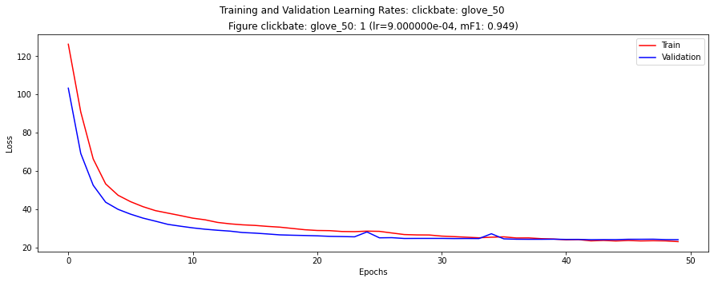

```python
default_lr = facade.learning_rate
default_epochs = facade.epochs
facade.learning_rate = facade.learning_rate - (facade.learning_rate/10)
facade.epochs = 50
mng.run()
```

## Add language features

Since adjusting the learning rate didn't show a significant positive change, restore the previous learning rate. Instead, we'll try to add spaCy generated language features by appending them to the embedding layer. The enumerations are one-hot encoded vectors of POS tags, NER entities and dependenccy parent/child relationship.

```
tr:16.281|va min:15.507|va: 16.03|lr: 0.001 /\: 100%|██████████| 35/35 [01:09<00:00,  1.98s/it]
```

```
Name: clickbate: glove_50: 1
Run index: 2
Learning rate: 0.001
    train:
        started: 08/08/2022 15:34:49:206852
        ended: 08/08/2022 15:35:57:609494
        batches: 128
        ave data points per batch/total: 200.0/25598
        min/ave/max loss: 7.17201/16.28149/29.96643
    validation:
        started: 08/08/2022 15:34:50:256920
        ended: 08/08/2022 15:35:57:640157
        batches: 17
        ave data points per batch/total: 188.3/3201
        converged/epochs: 28/35
        min/ave/max loss: 0.00003/15.50723/26.29385
        accuracy: 0.972 (3110/3201)
        micro: F1: 0.972, precision: 0.972, recall: 0.972
        macro: F1: 0.972, precision: 0.972, recall: 0.972
        weighted: F1: 0.972, precision: 0.972, recall: 0.972
    test:
        started: 08/08/2022 15:35:59:124071
        ended: 08/08/2022 15:35:59:153250
        batches: 17
        ave data points per batch/total: 188.3/3201
        min/ave/max loss: 0.00013/16.14104/31.10806
        accuracy: 0.970 (3106/3201)
        micro: F1: 0.970, precision: 0.970, recall: 0.970
        macro: F1: 0.970, precision: 0.970, recall: 0.970
        weighted: F1: 0.970, precision: 0.970, recall: 0.970
```

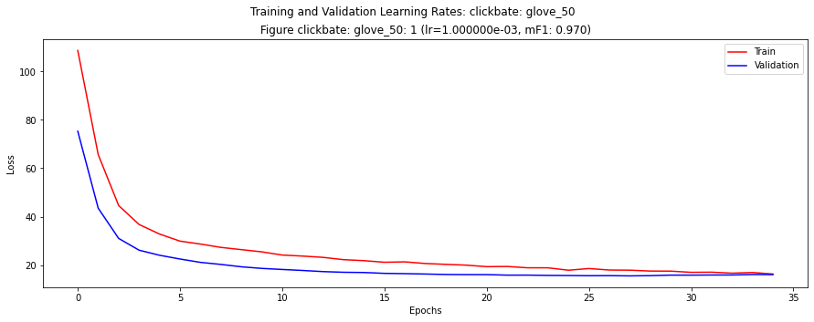

```python
facade.learning_rate = default_lr
facade.epochs = default_epochs
facade.language_attributes = {'enums'}
mng.run()
facade.persist_result()
```